# Asthama Disease Prediction using Machine Learning !!!!

.

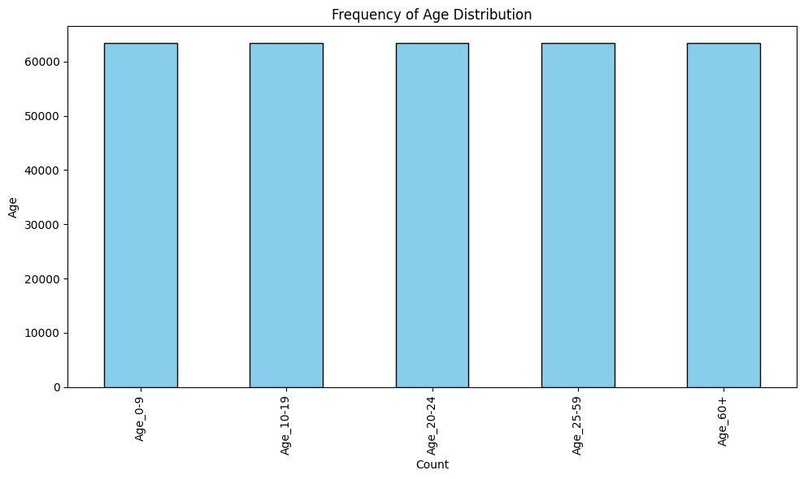

```python
fig, ax = plt.subplots(figsize=(10, 6))

age_distribution.sort_values().plot(kind='bar', ax=ax, color='skyblue',
                                  edgecolor='black')
ax.set_title('Frequency of Age Distribution')
ax.set_xlabel('Count')
ax.set_ylabel('Age')

plt.tight_layout()
plt.show()
```

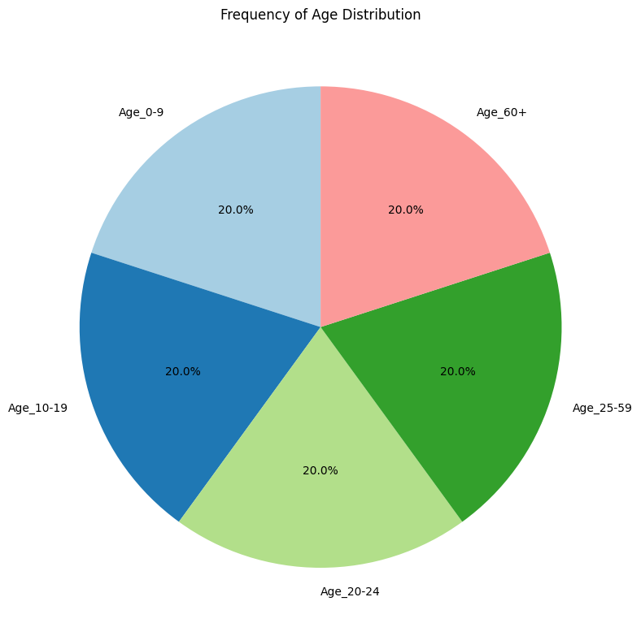

```python
fig, ax = plt.subplots(figsize=(8, 8))
ax.pie(age_distribution, labels=age_distribution.index, autopct='%1.1f%%',
       startangle=90,
       colors=plt.cm.Paired(range(len(age_distribution))))
ax.set_title('Frequency of Age Distribution')
plt.axis('equal')
plt.tight_layout()
plt.show()
```

```python
fig = px.bar(age_distribution, x=age_distribution.index, y=age_distribution.values,
             labels={'x': 'Age Distribution', 'y': 'Count'},
             title='Frequency of Age Distribution', color_discrete_sequence=['skyblue'])
fig.update_layout(xaxis_tickangle=-45)
fig.show()
```

[output not shown]

```python
custom_colors = ['#1f77b4', '#ff7f0e', '#2ca02c', '#d62728', '#9467bd', '#8c564b', '#e377c2', '#7f7f7f', '#bcbd22', '#17becf']
fig = px.pie(age_distribution, values=age_distribution.values, names=age_distribution.index,
             title='Frequency of Age Distribution', color_discrete_sequence=custom_colors)
fig.show()
```

[output not shown]

PLOT OF GENDER DISTRIBUTION

.

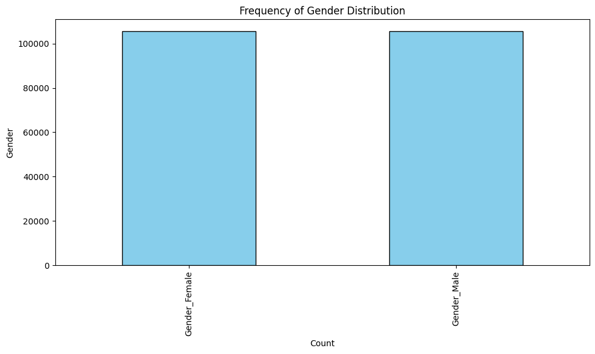

```python
fig, ax = plt.subplots(figsize=(10, 6))

gender_distribution.sort_values().plot(kind='bar', ax=ax, color='skyblue',
                                  edgecolor='black')
ax.set_title('Frequency of Gender Distribution')
ax.set_xlabel('Count')
ax.set_ylabel('Gender')

plt.tight_layout()
plt.show()
```

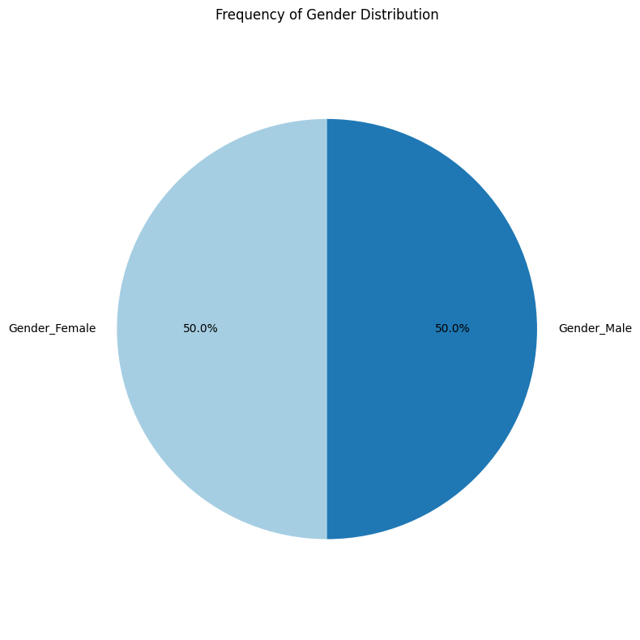

```python
fig, ax = plt.subplots(figsize=(8, 8))
ax.pie(gender_distribution, labels=gender_distribution.index, autopct='%1.1f%%',
       startangle=90,
       colors=plt.cm.Paired(range(len(age_distribution))))
ax.set_title('Frequency of Gender Distribution')
plt.axis('equal')
plt.tight_layout()
plt.show()
```

```python
fig = px.bar(gender_distribution, x=gender_distribution.index, y=gender_distribution.values,
             labels={'x': 'Gender Distribution', 'y': 'Count'},
             title='Frequency of Gender Distribution', color_discrete_sequence=['skyblue'])
fig.update_layout(xaxis_tickangle=-45)
fig.show()
```

[output not shown]

```python
custom_colors = ['#1f77b4', '#ff7f0e', '#2ca02c', '#d62728', '#9467bd', '#8c564b', '#e377c2', '#7f7f7f', '#bcbd22', '#17becf']
fig = px.pie(gender_distribution, values=gender_distribution.values, names=gender_distribution.index,
             title='Frequency of Gender Distribution', color_discrete_sequence=custom_colors)
fig.show()
```

[output not shown]

SO WE SAW AGE GROUPS AND GENDER ARE VERY EQUALLLY DISTRIBUTED

..

.corr():

This method calculates the correlation matrix for these columns. The correlation matrix is a square matrix where each entry represents the correlation coefficient between two columns. The correlation coefficient measures the degree of linear relationship between two variables, and it can range from -1 (perfect negative correlation) to 1 (perfect positive correlation), with 0 indicating no linear correlation.

The result of this code will be a DataFrame containing the correlation coefficients between the selected symptom columns in df. The matrix will show how each symptom correlates with every other symptom in the subset, providing insights into the relationships between these variables.

```python
corr = df[symptoms].corr()
```

```python
corr
```

|  | Tiredness | Dry-Cough | Difficulty-in-Breathing | Sore-Throat | Pains | Nasal-Congestion | Runny-Nose |
| --- | --- | --- | --- | --- | --- | --- | --- |
| Tiredness | 1.000000e+00 | 3.779645e-01 | 0.000000e+00 | -1.348400e-01 | 2.099071e-17 | 0.000000e+00 | 0.000000e+00 |
| Dry-Cough | 3.779645e-01 | 1.000000e+00 | 3.779645e-01 | 5.096472e-02 | 7.542460e-16 | 2.281412e-16 | -1.889722e-16 |
| Difficulty-in-Breathing | 0.000000e+00 | 3.779645e-01 | 1.000000e+00 | 4.045199e-01 | 1.399697e-17 | 0.000000e+00 | 0.000000e+00 |
| Sore-Throat | -1.348400e-01 | 5.096472e-02 | 4.045199e-01 | 1.000000e+00 | -4.451275e-16 | 5.102065e-16 | -1.020501e-16 |
| Pains | 2.099071e-17 | 7.542460e-16 | 1.399697e-17 | -4.451275e-16 | 1.000000e+00 | 3.105295e-01 | -6.900656e-02 |
| Nasal-Congestion | 0.000000e+00 | 2.281412e-16 | 0.000000e+00 | 5.102065e-16 | 3.105295e-01 | 1.000000e+00 | 2.666667e-01 |
| Runny-Nose | 0.000000e+00 | -1.889722e-16 | 0.000000e+00 | -1.020501e-16 | -6.900656e-02 | 2.666667e-01 | 1.000000e+00 |

PLOTTINGGGG

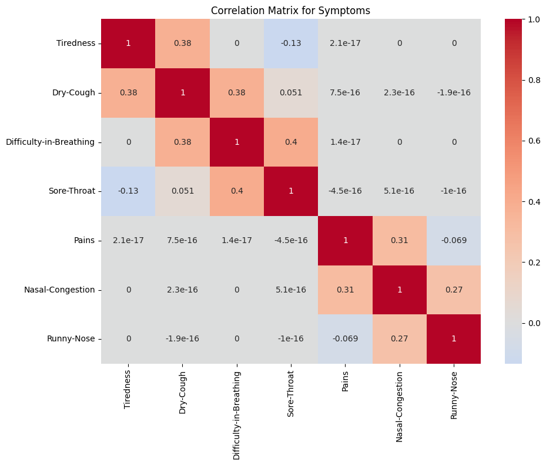

```python
fig, ax = plt.subplots(figsize=(10, 8))
sns.heatmap(corr, annot=True, cmap='coolwarm', center=0, ax=ax)
ax.set_title('Correlation Matrix for Symptoms')
plt.tight_layout()
plt.show()
```

Calculating mean for all the columns

```python
severity_symptom_means = df.groupby(by=[col for col in df.columns if "Asthma_Severity" in col])[symptoms].mean()
```

```python
severity_symptom_means
```

| Asthma_Severity | Tiredness | Dry-Cough | Difficulty-in-Breathing | Sore-Throat | Pains | Nasal-Congestion | Runny-Nose |
| --- | --- | --- | --- | --- | --- | --- | --- |
| 0 | 0.5 | 0.5625 | 0.5 | 0.3125 | 0.363636 | 0.545455 | 0.545455 |
| 1 | 0.5 | 0.5625 | 0.5 | 0.3125 | 0.363636 | 0.545455 | 0.545455 |

```python
severity_symptom_means
```

| Asthma_Severity | Tiredness | Dry-Cough | Difficulty-in-Breathing | Sore-Throat | Pains | Nasal-Congestion | Runny-Nose |
| --- | --- | --- | --- | --- | --- | --- | --- |
| 0 | 0.5 | 0.5625 | 0.5 | 0.3125 | 0.363636 | 0.545455 | 0.545455 |
| 1 | 0.5 | 0.5625 | 0.5 | 0.3125 | 0.363636 | 0.545455 | 0.545455 |

Simple transpose

```python
severity_symptom_means = severity_symptom_means.transpose()
```

```python
severity_symptom_means
```

| Asthma_Severity | 0 | 1 |
| --- | --- | --- |
| Tiredness | 0.500000 | 0.500000 |
| Dry-Cough | 0.562500 | 0.562500 |
| Difficulty-in-Breathing | 0.500000 | 0.500000 |
| Sore-Throat | 0.312500 | 0.312500 |
| Pains | 0.363636 | 0.363636 |
| Nasal-Congestion | 0.545455 | 0.545455 |
| Runny-Nose | 0.545455 | 0.545455 |

CREATING NEW DATA based on this mean table

```python
data = {
    'Asthma_Severity': [0, 1, 2],
    'Tiredness': [0.500000, 0.500000, 0.500000],
    'Dry-Cough': [0.562500, 0.562500, 0.562500],
    'Difficulty-in-Breathing': [0.500000, 0.500000, 0.500000],
    'Sore-Throat': [0.312500, 0.312500, 0.312500],
    'Pains': [0.363636, 0.363636, 0.363636],
    'Nasal-Congestion': [0.545455, 0.545455, 0.545455],
    'Runny-Nose': [0.545455, 0.545455, 0.545455]
}
```

```python
df1 = pd.DataFrame(data)
```

```python
df1.set_index('Asthma_Severity' , inplace=True)
```

```python
df1
```

| Asthma_Severity | Tiredness | Dry-Cough | Difficulty-in-Breathing | Sore-Throat | Pains | Nasal-Congestion | Runny-Nose |
| --- | --- | --- | --- | --- | --- | --- | --- |
| 0 | 0.5 | 0.5625 | 0.5 | 0.3125 | 0.363636 | 0.545455 | 0.545455 |
| 1 | 0.5 | 0.5625 | 0.5 | 0.3125 | 0.363636 | 0.545455 | 0.545455 |
| 2 | 0.5 | 0.5625 | 0.5 | 0.3125 | 0.363636 | 0.545455 | 0.545455 |

PLOTTT

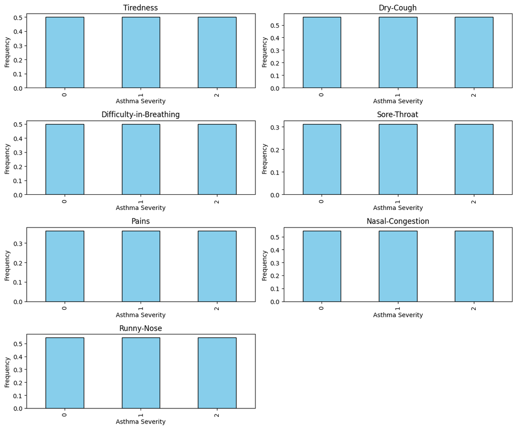

```python
fig, axes = plt.subplots(nrows=4, ncols=2, figsize=(12, 10))
symptoms = ['Tiredness', 'Dry-Cough', 'Difficulty-in-Breathing', 'Sore-Throat', 'Pains', 'Nasal-Congestion', 'Runny-Nose']

for i, symptom in enumerate(symptoms):
    row, col = divmod(i, 2)
    df1[symptom].plot(kind='bar', ax=axes[row, col], color='skyblue', edgecolor='black')
    axes[row, col].set_title(symptom)
    axes[row, col].set_xlabel('Asthma Severity')
    axes[row, col].set_ylabel('Frequency')

if len(symptoms) < len(axes.flat):
    for i in range(len(symptoms), len(axes.flat)):
        fig.delaxes(axes.flatten()[i])

plt.tight_layout()
plt.show()
```

old df

```python
df
```

|  | Tiredness | Dry-Cough | Difficulty-in-Breathing | Sore-Throat | None_Sympton | Pains | Nasal-Congestion | Runny-Nose | None_Experiencing | Age_0-9 | Age_10-19 | Age_20-24 | Age_25-59 | Age_60+ | Gender_Female | Gender_Male | Asthma_Severity |
| --- | --- | --- | --- | --- | --- | --- | --- | --- | --- | --- | --- | --- | --- | --- | --- | --- | --- |
| 0 | 1 | 1 | 1 | 1 | 0 | 1 | 1 | 1 | 0 | 1 | 0 | 0 | 0 | 0 | 0 | 1 | 0 |
| 1 | 1 | 1 | 1 | 1 | 0 | 1 | 1 | 1 | 0 | 1 | 0 | 0 | 0 | 0 | 0 | 1 | 0 |
| 2 | 1 | 1 | 1 | 1 | 0 | 1 | 1 | 1 | 0 | 1 | 0 | 0 | 0 | 0 | 0 | 1 | 0 |
| 3 | 1 | 1 | 1 | 1 | 0 | 1 | 1 | 1 | 0 | 1 | 0 | 0 | 0 | 0 | 0 | 1 | 1 |
| 4 | 1 | 1 | 1 | 1 | 0 | 1 | 1 | 1 | 0 | 1 | 0 | 0 | 0 | 0 | 0 | 1 | 1 |
| ... | ... | ... | ... | ... | ... | ... | ... | ... | ... | ... | ... | ... | ... | ... | ... | ... | ... |
| 316795 | 0 | 0 | 0 | 0 | 1 | 0 | 0 | 0 | 1 | 0 | 0 | 0 | 0 | 1 | 0 | 0 | 0 |
| 316796 | 0 | 0 | 0 | 0 | 1 | 0 | 0 | 0 | 1 | 0 | 0 | 0 | 0 | 1 | 0 | 0 | 0 |
| 316797 | 0 | 0 | 0 | 0 | 1 | 0 | 0 | 0 | 1 | 0 | 0 | 0 | 0 | 1 | 0 | 0 | 0 |
| 316798 | 0 | 0 | 0 | 0 | 1 | 0 | 0 | 0 | 1 | 0 | 0 | 0 | 0 | 1 | 0 | 0 | 0 |
| 316799 | 0 | 0 | 0 | 0 | 1 | 0 | 0 | 0 | 1 | 0 | 0 | 0 | 0 | 1 | 0 | 0 | 0 |

316800 rows × 17 columns

Feature Selection

Where Asthma Severity will be our Target Variable

```python
x = df.drop(['Asthma_Severity'] , axis = 1)

y = df['Asthma_Severity']
```

# MODEL TRAINING

https://scikit-learn.org/stable/modules/generated/sklearn.ensemble.RandomForestClassifier.html

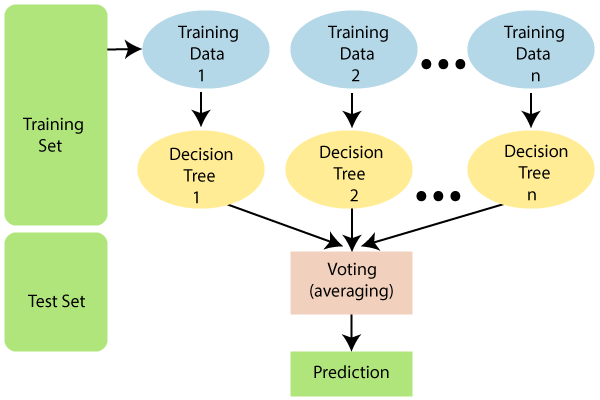

RANDOM FOREST IS A DECISION MADE FROM MULTIPLE DECISION TREEES

. .

```python
from sklearn.ensemble import RandomForestClassifier
```

n_estimators=100: This parameter specifies the number of decision trees (estimators) to include in the random forest.

random_state=42: This parameter sets the random seed for the random number generator used by the random forest algorithm.

```python
clf = RandomForestClassifier(n_estimators=100 , random_state=42)
```

```python
clf.fit(x , y)
```

```
RandomForestClassifier(random_state=42)
```

is used to retrieve the feature importances from a trained Random Forest classifier (clf) after it has been fit to a dataset. Feature importances provide information about the contribution of each feature (or variable) in the dataset to the model's predictions. These importances are typically expressed as values between 0 and 1, and they sum up to 1 across all features.

```python
feature_importances = clf.feature_importances_
```

```python
feature_importance_df = pd.DataFrame({'Feature' : x.columns , "Importance" : feature_importances})
```

```python
feature_importance_df = feature_importance_df.sort_values(by='Importance', ascending=False)
```

```python
feature_importance_df
```

|  | Feature | Importance |
| --- | --- | --- |
| 6 | Nasal-Congestion | 0.097225 |
| 5 | Pains | 0.096774 |
| 7 | Runny-Nose | 0.094631 |
| 0 | Tiredness | 0.088506 |
| 14 | Gender_Female | 0.086758 |
| 2 | Difficulty-in-Breathing | 0.085456 |
| 3 | Sore-Throat | 0.085436 |
| 15 | Gender_Male | 0.082218 |
| 1 | Dry-Cough | 0.079887 |
| 8 | None_Experiencing | 0.038831 |
| 9 | Age_0-9 | 0.029175 |
| 10 | Age_10-19 | 0.027898 |
| 12 | Age_25-59 | 0.027824 |
| 4 | None_Sympton | 0.027545 |
| 11 | Age_20-24 | 0.025962 |
| 13 | Age_60+ | 0.025874 |

PLOTT THE SAME

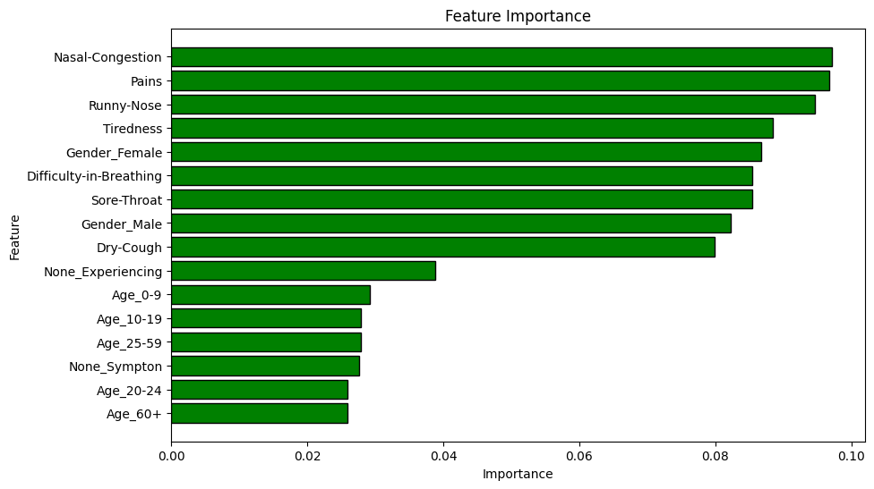

```python
plt.figure(figsize=(10, 6))
plt.barh(feature_importance_df['Feature'], feature_importance_df['Importance'], color='green', edgecolor='black')
plt.xlabel('Importance')
plt.ylabel('Feature')
plt.title('Feature Importance')
plt.gca().invert_yaxis()
```

```python
X = df[symptoms + gender_groups]
```

```python
from sklearn.linear_model import LogisticRegression
from sklearn.tree import DecisionTreeClassifier
from sklearn.model_selection import train_test_split
```

Splitting Data into Train and Test Sets

.

.

https://scikit-learn.org/stable/modules/generated/sklearn.model_selection.train_test_split.html

```python
X_train,X_test,y_train,y_test=train_test_split(X,
                                               y,
                                               test_size=0.2,
                                               stratify = y,
                                               random_state=42)
```

```python
from sklearn.metrics import accuracy_score , confusion_matrix , classification_report
```

LOGISTIC REGRESSION

.

https://scikit-learn.org/stable/modules/generated/sklearn.linear_model.LogisticRegression.html

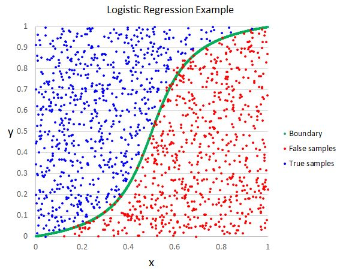

Logistic Regression is one of the basic and popular algorithms to solve a classification problem

```python
lr = LogisticRegression(random_state=42)
```

```python
lr.fit(X_train , y_train)
```

```
LogisticRegression(random_state=42)
```

```python
y_pred_lr = lr.predict(X_test)
```

```python
accuracy = accuracy_score(y_test , y_pred_lr)
print(f'Accuracy : {accuracy :.2f}')
```

```
Accuracy : 0.75
```

DECISION TREE

.

Decision Trees (DTs) are a non-parametric supervised learning method used for classification and regression.

https://scikit-learn.org/stable/modules/tree.html

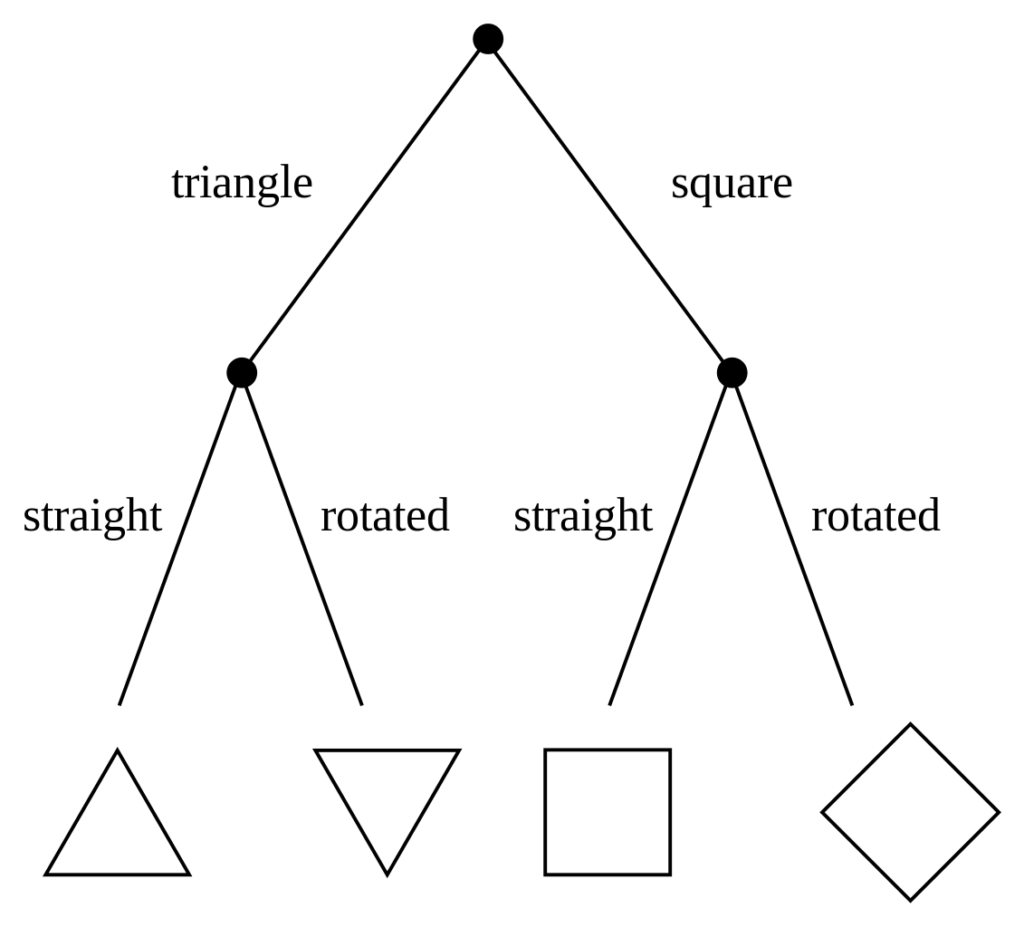

```python
dt = DecisionTreeClassifier()
```

```python
model_dt = dt.fit(X_train , y_train)
```

```python
y_pred_dt  = model_dt.predict(X_test)
```

```python
accuracy = accuracy_score(y_test, y_pred_dt)
print(f'Accuracy: {accuracy:.2f}')
```

```
Accuracy: 0.75
```

XGBoost

is an optimized distributed gradient boosting library designed for efficient and scalable training of machine learning models.

https://www.geeksforgeeks.org/xgboost/

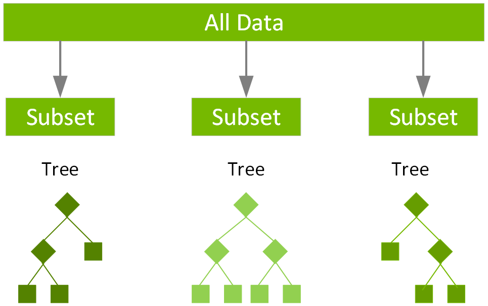

```python
import xgboost as xgb
```

```python
clf = xgb.XGBClassifier(
    objective='multi:softmax',
    num_class=len(pd.unique(y)),
    eval_metric='mlogloss',
    use_label_encoder=False
)
```

```python
clf.fit(X_train, y_train)
```

```
XGBClassifier(base_score=None, booster=None, callbacks=None,
              colsample_bylevel=None, colsample_bynode=None,
              colsample_bytree=None, device=None, early_stopping_rounds=None,
              enable_categorical=False, eval_metric='mlogloss',
              feature_types=None, gamma=None, grow_policy=None,
              importance_type=None, interaction_constraints=None,
              learning_rate=None, max_bin=None, max_cat_threshold=None,
              max_cat_to_onehot=None, max_delta_step=None, max_depth=None,
              max_leaves=None, min_child_weight=None, missing=nan,
              monotone_constraints=None, multi_strategy=None, n_estimators=None,
              n_jobs=None, num_class=2, num_parallel_tree=None, ...)
```

```python
y_pred_xgb = clf.predict(X_test)
```

```python
accuracy = accuracy_score(y_test, y_pred_xgb)
print(f'Accuracy: {accuracy:.2f}')
```

```
Accuracy: 0.75
```

So , in summary we were able to create a machine learning model for "Asthama Prediciton using supervised Data" where we tried multiple machine learning techniques like LOGISTIC REGRESSION , DECISION TREES , XGBOOST and we could achieve an accuracy of

0.75